# Spatial analysis of mining sites data in DR Congo

Trésor Djonga

The aim of this work is to present insights from collected data of artisanal mining sites in DR Congo using commonly used spatial techniques. Each method is brievly presented.

## Data loading and pre-processing

```r
#import necessairy librairies
library(rgdal)
library(sp)
library(dplyr)
library(tidyr)
library(tmap)
library(maptools)
options(warn=-1)
```

Set working directory

```r
setwd("C:/Users/Djonga/Desktop/proposal/ProjetDRCMining")
```

We will work with IPIS’ artisanal mining sites spatial data and territories data of DRC. Artisanal mining sites data can be download [here] (https://ipisresearch.be/home/maps-data/open-data/), also [here](https://github.com/jorisvandenbossche/geopandas-tutorial).

```r
dataIPIS <- readOGR("cod_mines_curated_all_opendata_p_ipis.geojson")
```

Verify that every thing is ok.

```r
head(dataIPIS)
```

```
## class       : SpatialPointsDataFrame
## features    : 6
## extent      : 28.18514, 29.42106, -0.352529, 0.864456  (xmin, xmax, ymin, ymax)
## crs         : +proj=longlat +datum=WGS84 +no_defs
## variables   : 61
## names       :                                                                  id, vid,                      source,     project,        pcode,      name, visit_date, visit_onsite, visit_onsite_novisitreason,       longitude,  latitude,     location_origin,  province, province_old, territoire, ..…
## min values  : cod_mines_curated_all_opendata_p_ipis.fid-11f0e8d4_16301c8608d_69e8,   1, IPIS - MinistÃ¨re des Mines, IPIS - 2009, codmine00191,      Eita, 2009/01/01,            1,                         NA, 28.185142299499, -0.352529,                 GPS, Nord-Kivu,    Nord-Kivu,       Beni, ..…
## max values  : cod_mines_curated_all_opendata_p_ipis.fid-11f0e8d4_16301c8608d_69ed,   6, IPIS - MinistÃ¨re des Mines, IPIS - 2009, codmine00286, Mungu Iko, 2009/01/01,            1,                         NA,       29.421061,  0.864456, GPS (Approximation), Nord-Kivu,    Nord-Kivu,     Lubero, ..…
```

We will work with the following variables:

1. *pcode*:internal IPIS’ identifiant of artisanal mining sites.
2. *visit_date*: latest visited of artisanal mining sites.
3. *workers_numb*: number of all peoples working in the in the artisanal mining sites
4. *is_3t_mine*: Is there one of 3T mines (Cassiterite, Wolframite, Coltan))?
5. *is_gold_mine*: Is there à gold?
6. *presence*: Is there a state or not state army group?

```r
dataIPIS <- dataIPIS[,c("pcode","visit_date", "workers_numb","is_3t_mine","is_gold_mine","presence")]
head(dataIPIS)
```

```
## class       : SpatialPointsDataFrame
## features    : 6
## extent      : 28.18514, 29.42106, -0.352529, 0.864456  (xmin, xmax, ymin, ymax)
## crs         : +proj=longlat +datum=WGS84 +no_defs
## variables   : 6
## names       :        pcode, visit_date, workers_numb, is_3t_mine, is_gold_mine, presence
## min values  : codmine00191, 2009/01/01,           50,          0,            1,        0
## max values  : codmine00286, 2009/01/01,          300,          1,            1,        1
```

We will delete all NA values in each columns.

```r
dataIPIS <-subset(dataIPIS, !is.na(visit_date) & !is.na(workers_numb)& !is.na(is_3t_mine)& !is.na(is_gold_mine)& !is.na(presence) )
```

Getting dimension after “NA” supression.

```r
dim(dataIPIS)
```

```
## [1] 3029    6
```

We keep artisanal mining with number of workers less then 1000

```r
dataIPIS <-subset(dataIPIS,workers_numb < 1000)
```

Some artisanal mining sites were visited several time, so we will keep the latest visit. We sort by pcode in ascending order then visit_date by descending

```r
dataIPIS <- dataIPIS[order(dataIPIS@data$pcode, -as.numeric(dataIPIS@data$visit_date)),]
head(dataIPIS)
```

```
## class       : SpatialPointsDataFrame
## features    : 6
## extent      : 29.64494, 29.72741, 0.956, 1.39528  (xmin, xmax, ymin, ymax)
## crs         : +proj=longlat +datum=WGS84 +no_defs
## variables   : 6
## names       :        pcode, visit_date, workers_numb, is_3t_mine, is_gold_mine, presence
## min values  : codmine00001, 2013/03/27,          115,          0,            1,        1
## max values  : codmine00006, 2013/03/28,          270,          0,            1,        1
```

We group by pcode and take first.

```r
dataIPIS <- dataIPIS[!duplicated(dataIPIS@data$pcode),]
```

The dimension of the cleaned spatial dataset.

```r
dim(dataIPIS)
```

```
## [1] 2184    6
```

Plotting artisanal mining sites.

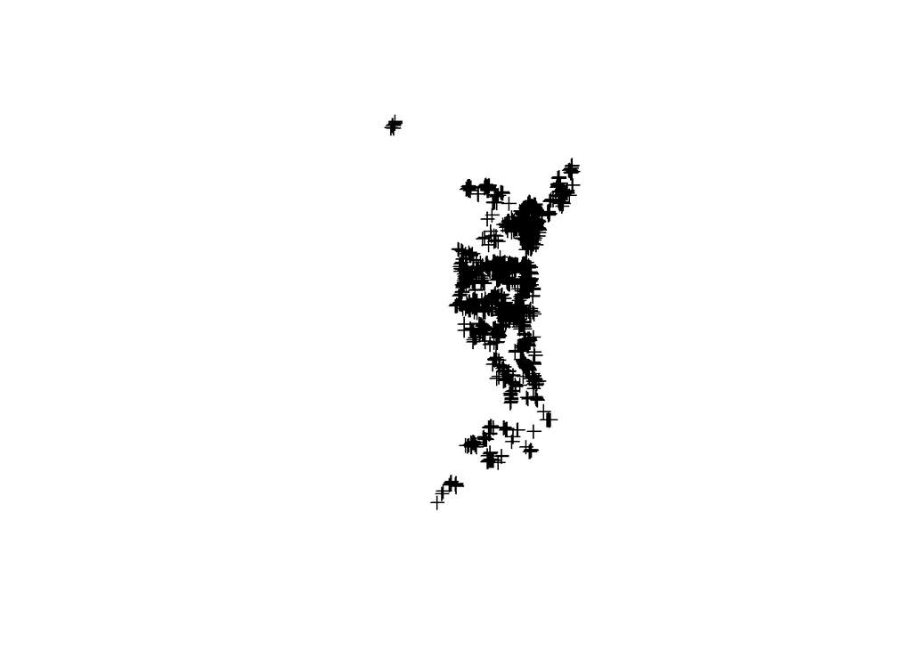

```r
plot(dataIPIS)
```

Reading shapefile of DRC territories

```r
territories <-readOGR("./territoire", "Territoire")
head(territories)
```

```
## class       : SpatialPolygonsDataFrame
## features    : 6
## extent      : 2476470, 3076433, -1317649, -636676  (xmin, xmax, ymin, ymax)
## crs         : +proj=merc +lat_ts=0 +lon_0=0 +x_0=0 +y_0=0 +datum=WGS84 +units=m +no_defs
## variables   : 8
## names       :        NOM,     TYPE, CODE_INS, SCE_SEM, SCE_GEO,      MODIF,   SURFACE,                   ORIGINE
## min values  :    Kananga, Communes,     7010,     INS,    UNDP, 2010/06/18, 119.04601, Numerisation Saint Moulin
## max values  : Mwene Ditu, Communes,     9010,     INS,    UNDP, 2010/06/18, 856.78134, Numerisation Saint Moulin
```

The DRC territories shapefile contains also groupement, district. We will keep only territories. There are 145 territories in DRC.

```r
territories <- subset(territories, TYPE=="Territoire")
table(territories@data$TYPE)
```

```
##
## Territoire
##        145
```

Plotting artisanal territories.

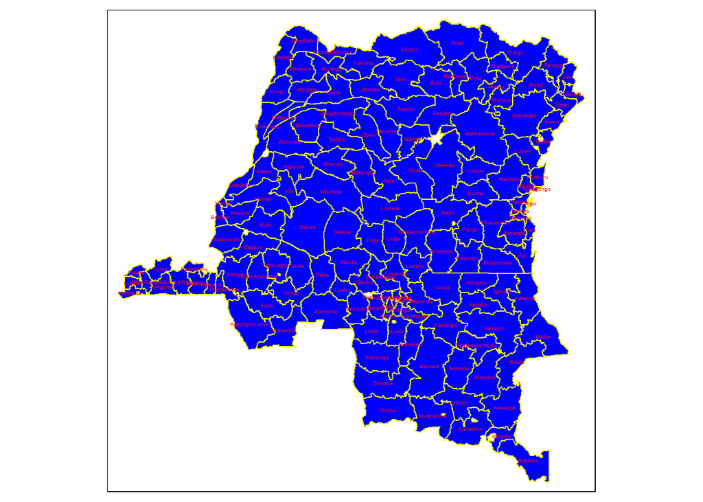

```r
tm_shape(territories) + tm_polygons(col="blue", border.col="yellow") + tm_text("NOM", col = "red", size = .30)
```

Reprojection territoire to dataIPIS’ CRS.

```r
crsIPIS <- CRS(proj4string(dataIPIS))
territories <- spTransform(territories, crsIPIS)
```

In territories we kept only Type and name attributes.

```r
territories@data <- territories@data[,c("TYPE","NOM")]
```

Giving mining site the territoiry’s attributes. To work in territory level, we created the following new variables:

1. meanWorkers_numb: mean number of workers working in artisanal mining site for each territory.
2. sumIs_3t_mine: Number of artisanal mining site which contains 3T mines in the territory.
3. sumIs_gold_mine: Number of artisanal mining site which contains gold in the territory.
4. sumPresence: Number of artisanal mining site which contains no state army group in the territory.

```r
pip <- sp::over(territories, dataIPIS[, c("is_3t_mine", "is_gold_mine", "presence")], fn = sum)
```

Bind the census data to dataIPS.

```r
territories <- maptools::spCbind(territories, pip)
```

Mean number of workers in artisanal mining site by territories.

```r
pip <- sp::over(territories, dataIPIS[, "workers_numb" ], fn = mean)
territories <- maptools::spCbind(territories, pip)
```

Extracting subset of variables for subsequent analysis.

```r
territories@data <- territories@data[,c("NOM","is_3t_mine","is_gold_mine","presence","workers_numb")]
```

Renaming columns.

```r
names(territories@data)<-c("NOM","sumIs_3t_mine","sumIs_gold_mine","sumPresence","meanWorkers_numb")
```

Mapping territoiries.

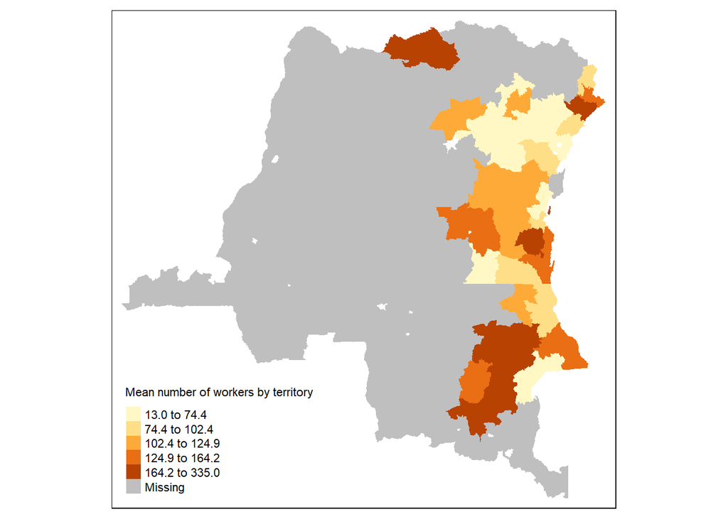

```r
tm_shape (territories) + tm_fill (col = "meanWorkers_numb", style = "quantile", title = "Mean number of workers by territory")
```

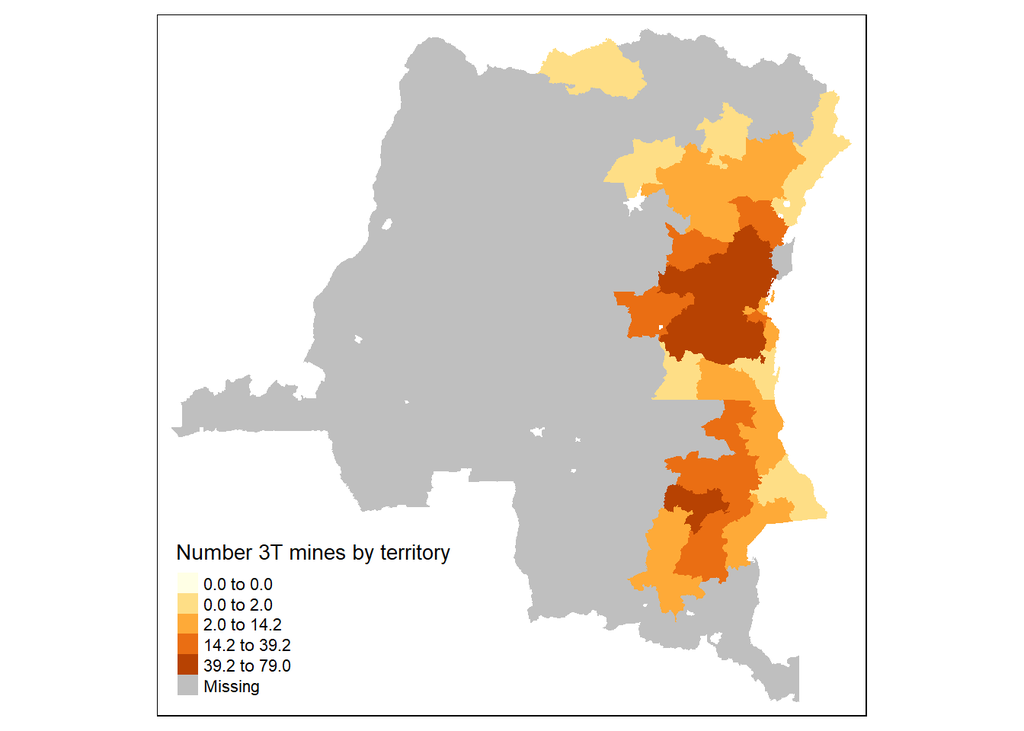

```r
tm_shape (territories) + tm_fill (col = "sumIs_3t_mine", style = "quantile", title = "Number 3T mines by territory")
```

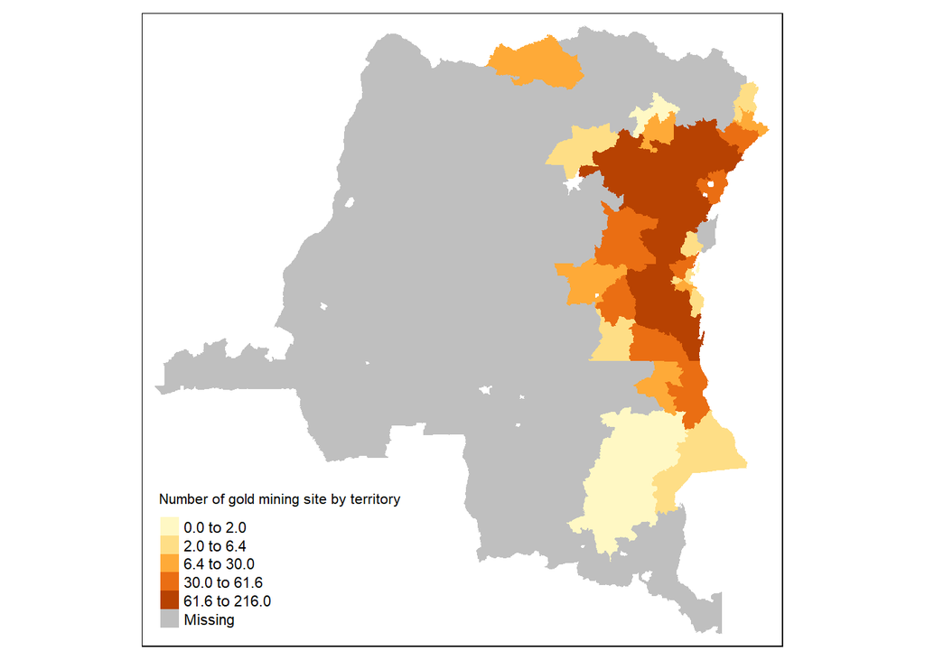

```r
tm_shape (territories) + tm_fill (col = "sumIs_gold_mine", style = "quantile", title = "Number of gold mining site by territory")
```

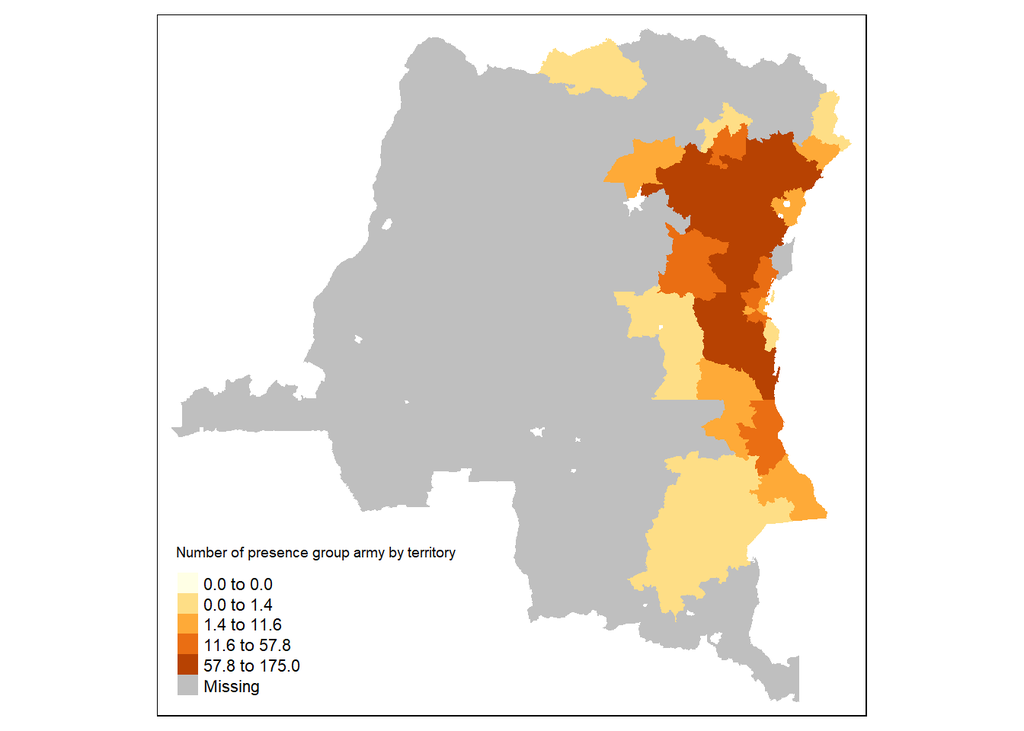

```r
tm_shape (territories) + tm_fill (col = "sumPresence", style = "quantile", title = "Number of presence group army by territory")
```

Territory containing the largest mean number of workers.

```r
subset(territories@data, meanWorkers_numb == max(meanWorkers_numb, na.rm=TRUE))
```

```
##        NOM sumIs_3t_mine sumIs_gold_mine sumPresence meanWorkers_numb
## 110 Lubudi             3               0           0              335
```

Territory containing the largest number 3T Mines.

```r
subset(territories@data, sumIs_3t_mine == max(sumIs_3t_mine, na.rm=TRUE))
```

```
##         NOM sumIs_3t_mine sumIs_gold_mine sumPresence meanWorkers_numb
## 98 Shabunda            79             171         168         102.9514
```

Territory containing the largest number of gold.

```r
subset(territories@data, sumIs_gold_mine == max(sumIs_gold_mine, na.rm=TRUE))
```

```
##        NOM sumIs_3t_mine sumIs_gold_mine sumPresence meanWorkers_numb
## 84 Mambasa             2             216          96         66.06944
```

Territory containing the largest number of army group.

```r
subset(territories@data, sumPresence == max(sumPresence, na.rm=TRUE))
```

```
##         NOM sumIs_3t_mine sumIs_gold_mine sumPresence meanWorkers_numb
## 89 Walikale            71             205         175          106.261
```

## Spatial autocorrelation

The spatial autocorrelation will help us to undestand if there is a variation of our variable of interest across the space. We will discover if territories with artisanal mining which contains 3T and gold mines are close each other or if they are randomnly distributed across DRC. We will also see if territories with artisanal mining site with higher mean number are close each other.

To measure the spatial autocorrelation, we will use Moran’s coefficient denoted as I which is the extension of Pearson’s correlation denoted $\rho$. Recall that:
$$\rho(x,y) = \frac{\sum_{i=1}^{n}(x_{i} - \bar{x}) (y_{i} - \bar{y}) }{\sqrt {\sum_{i=1}^{n} (x_{i} - \bar{x})^{2} (y_{i} - \bar{y})^{2}}}$$

where $x = (x_{1},\ldots,x_{n})$, $x = (y_{1},\ldots,y_{n})$, $\bar{x}$ sample mean of $x$ and $\bar{y}$ sample mean of $y$.

For a single variable, say x, $I$ will measure whether $x_i$ and $x_j$ , with $i \neq j$, are associated, in other words the correlation of $x$ with herself spatially. $x$ may be 3T mines, mean number of workers,… Waldo Tober’s first law of geography is about “Everything is related to everything else, but near things are more related than distant things.” So logically expect that close observations are more likely to be similar with $x$ than those far apart. Moran introduced weight $\omega_{ij}$ to take into account the nearest spatial objects (territories here) $x_i$ and $x_j$. Moran I’s formula is given by:
$$I = \frac{n\sum_{i=1}^{n}\sum_{j=1}^{n} \omega_{ij} (x_{i} - \bar{x}) (x_{j} - \bar{y}) }{ \Omega\sum_{i=1}^{n} (x_{i} - \bar{x})^{2} }$$
We set $\omega_{ii} = 0$ and $\Omega = \sum_{i=1}^{n}\sum_{j=1}^{n} \omega_{ij}$.

Closest territories will have weight 1 and O otherwise. $w_{ij}$ can be taken equal to $\frac{1}{d_{ij}}$ where $d_{ij}$ is the distance between $x_i$ and $x_j$. Moran I’s observed value will be compared to
$$I_{0} = \frac{-1}{n-1}$$
.

We put out territories without artisanal mining sites.

```r
territories <-subset(territories, !is.na(meanWorkers_numb) & !is.na(sumIs_3t_mine)& !is.na(sumIs_gold_mine)& !is.na(sumPresence) )
```

Viewing the remaining part.

```r
territories@data
```

```
##               NOM sumIs_3t_mine sumIs_gold_mine sumPresence meanWorkers_numb
## 64        Banalia             0               6           6        107.50000
## 65     Bafwasende             2              63          65         72.63889
## 73          Bondo             0              12           0        283.66667
## 77          Rungu             0               0           1         13.00000
## 82          Wamba             0              14          14        124.78571
## 83          Irumu             0              85          69        101.29412
## 84        Mambasa             2             216          96         66.06944
## 85          Djugu             0              47           4        299.23404
## 86         Mahagi             0              13           0        156.15385
## 87            Aru             0               4           0         97.50000
## 89       Walikale            71             205         175        106.26103
## 90         Lubero            25             129         124         81.51656
## 91          Oicha             0              30          11         71.80000
## 93         Masisi            59               3          12         71.29508
```

[output cut: 23 more lines]

Mapping the remaining part of DRC.

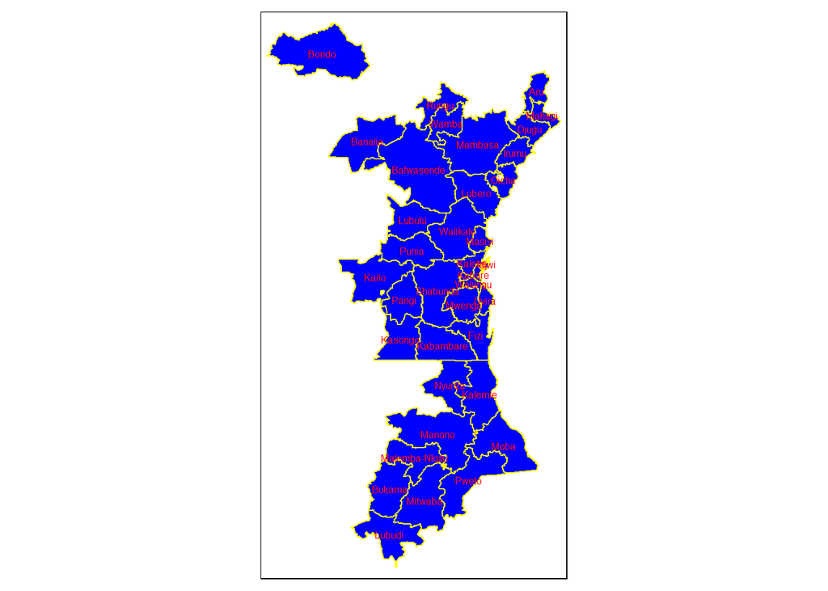

```r
#plot(territories)
tm_shape(territories) + tm_polygons(col="blue", border.col="yellow") + tm_text("NOM", col = "red", size = .50)
```

```r
library(spdep)
```

We start by finding neighbours for each DRC’s territories.

```r
neighbours <- poly2nb(territories)
neighbours
```

```
## Neighbour list object:
## Number of regions: 37
## Number of nonzero links: 134
## Percentage nonzero weights: 9.788167
## Average number of links: 3.621622
## 2 regions with no links:
## 73 100
```

The links between neighbours visualises distribution across space.

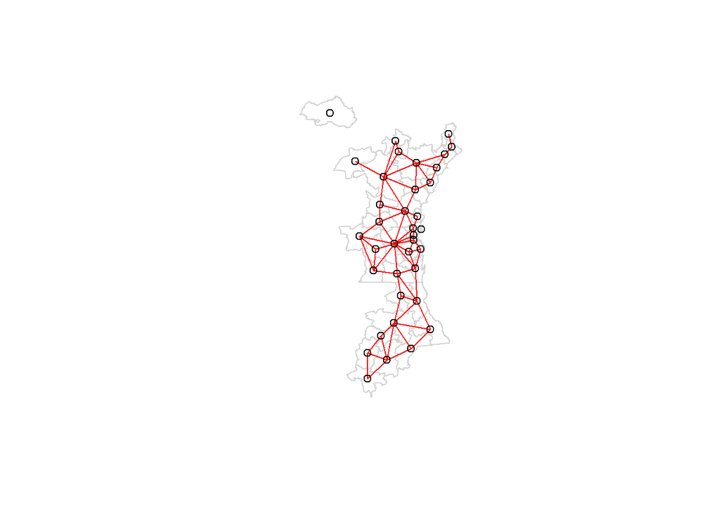

```r
plot(territories, border = 'lightgrey')
plot(neighbours, coordinates(territories), add=TRUE, col='red')
```

. We start firstly to work with the whole dataset.The Moran’s correlation score lies between -1 and 1.

1. The 1 determines perfect postive spatial autocorrelation, simular values are grouped or clustered together.
2. The 0 indicates randomnly distributed of values.
3. -1 represents negative spatial autocorrelation (so dissimilar values are next to each other)

```r
#territories <-subset(territories, NOM != "Bondo")
#https://mgimond.github.io/Spatial/mapping-data-in-r.html
```

The neighbour data need to be converted to a listw object.

```r
listw <- nb2listw(neighbours, zero.policy=TRUE)
print(listw, zero.policy=TRUE)
```

```
## Characteristics of weights list object:
## Neighbour list object:
## Number of regions: 37
## Number of nonzero links: 134
## Percentage nonzero weights: 9.788167
## Average number of links: 3.621622
## 2 regions with no links:
## 73 100
##
## Weights style: W
## Weights constants summary:
##    n   nn S0       S1       S2
## W 35 1225 35 20.84333 151.4485
```

Global Moran’s test for mean number of workers across territories.

The moran’s is significant at level 5%. the p-value is 0.03166. Moran’s statistic is 0.19553943 greater than the expectation -0.02941176, we can therefore confirm that mean number of workers across territories is positively autocorrelated in DRC. Territories with similar values of mean number of workers are grouped.

```r
moran.test(territories$meanWorkers_numb, listw, zero.policy=TRUE)
```

```
##
##  Moran I test under randomisation
##
## data:  territories$meanWorkers_numb
## weights: listw  n reduced by no-neighbour observations
##
##
## Moran I statistic standard deviate = 1.8569, p-value = 0.03166
## alternative hypothesis: greater
## sample estimates:
## Moran I statistic       Expectation          Variance
##        0.19553943       -0.02941176        0.01467585
```

Global Moran’s test for sumIs_gold_mine across territories.

```r
moran.test(territories$sumIs_gold_mine, listw, zero.policy=TRUE)
```

```
##
##  Moran I test under randomisation
##
## data:  territories$sumIs_gold_mine
## weights: listw  n reduced by no-neighbour observations
##
##
## Moran I statistic standard deviate = 1.9983, p-value = 0.02284
## alternative hypothesis: greater
## sample estimates:
## Moran I statistic       Expectation          Variance
##        0.20435250       -0.02941176        0.01368482
```

Global Moran’s test for 3T mines across territories.

The moran’s is significant. the p-value is 9.567e-05. Moran’s statistic is 0.42712496 greater than the expectation -0.02941176 , we can therefore confirm that number of artisanal mining site containing 3T mines across territories is positively autocorrelated in DRC. Territories with similar values of number 3T mines in artisanal mining are grouped.

```r
moran.test(territories$sumIs_3t_mine, listw, zero.policy=TRUE)
```

```
##
##  Moran I test under randomisation
##
## data:  territories$sumIs_3t_mine
## weights: listw  n reduced by no-neighbour observations
##
##
## Moran I statistic standard deviate = 3.7302, p-value = 9.567e-05
## alternative hypothesis: greater
## sample estimates:
## Moran I statistic       Expectation          Variance
##        0.42712496       -0.02941176        0.01497933
```

Global Moran’s test for sumPresence across territories.

```r
moran.test(territories$sumPresence, listw, zero.policy=TRUE)
```

```
##
##  Moran I test under randomisation
##
## data:  territories$sumPresence
## weights: listw  n reduced by no-neighbour observations
##
##
## Moran I statistic standard deviate = 1.8835, p-value = 0.02981
## alternative hypothesis: greater
## sample estimates:
## Moran I statistic       Expectation          Variance
##        0.18889882       -0.02941176        0.01343375
```

## Spatial kernel density estimation

We are interested to cover a land with high density of artisanal mining sites in DRC. Kernel density is one of the most spatial method used for points pattern analysis and it produces a hot spots maps. The idea behind this method is from a set of discrete points $x_{1},\ldots,x_{i},\ldots,x_{n}$ to produce a continuous density map or raster $\hat{f}(x)$ in which each pixel represents a density value based on the number of points within a given distance window width.

Given $x_{1},\ldots,x_{i},\ldots,x_{n}$, $x_{i} \in \mathbf{R}^{d}$, $\hat{f}(x)$ is given by:
$$\hat{f}(x) = \frac{1}{nh^{d}} \sum_{i=1}^{n} \mathbf{K}\{\frac{(x-x_{i})}{h}\}$$
-$ℎ$ is the bandwidth;
-$\mathbf{K}$is the Kernel function;
-$(x-x_{i})$ represents the Euclidian distance between each point $i$ and the location where the density estimator is worked out.

For hotspot analysis, the case mostly used is: -$d = 2$;  
- The bivariate normal kernel $\mathbf{K}(x) = \frac{1}{2\pi} \exp(-\frac{1}{2}x^{t}x)$;  
- The reference bandwith $h = \left(0.5 (sd_{x_{1}} + sd_{x_{2}})\right)n^{−1/6}$ where $sd_{x_{1}}$ and $sd_{x_{2}}$ are respectively standard deviation of the coordinates $x_1$ and $x_2$.

We will work artisanal mining sites dataIPIS .

```r
library(adehabitatHR)
```

We are working with artisanal mining locations, so we create their unique id names Hot spot.

```r
dataIPIS@data$id <-rep("Hotspot",dim(dataIPIS)[1])
head(dataIPIS[,"id"])
```

```
##            coordinates      id
## 657 (29.6603, 1.01089) Hotspot
## 658 (29.6586, 1.00308) Hotspot
## 659 (29.6563, 0.98563) Hotspot
## 660 (29.6449, 0.99976) Hotspot
## 661     (29.66, 0.956) Hotspot
## 676 (29.7274, 1.39528) Hotspot
## Coordinate Reference System (CRS) arguments: +proj=longlat +datum=WGS84
## +no_defs
```

kernel density estimation with default values.

```r
kernelDRC = kernelUD(dataIPIS[,"id"])
```

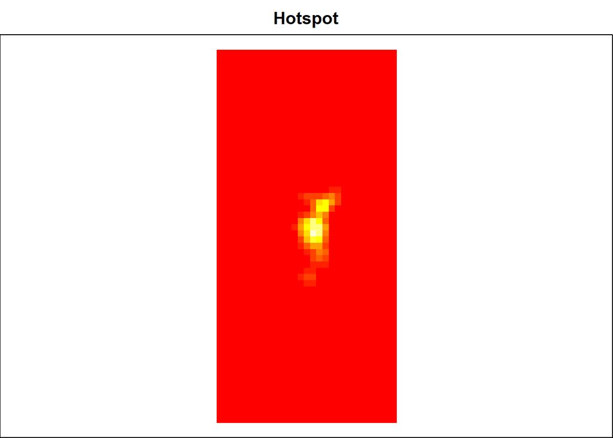

```r
image(kernelDRC)
```

Convert the result into an object of class SpatialPixelsDataFrame.

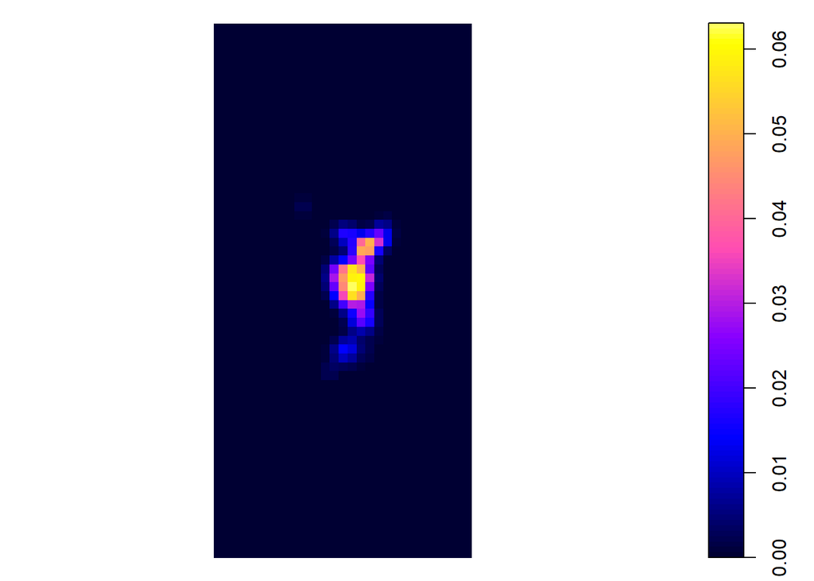

```r
pixelkernel<-estUDm2spixdf(kernelDRC)
plot(pixelkernel)
```

Convert to raster type and set CRS.

```r
library(raster)
kde <- raster(pixelkernel)

projection(kde) <- CRS(proj4string(dataIPIS))
```

Maps of the masked raster and maps white output area boundaries

```r
# maps the masked raster
masked_kde <- mask(kde, territories)
```

creates a bounding box based on the extents of the territories.

```r
bounding_box <- bbox(territories)
```

Mapping hot spot backed by DRC territories map.

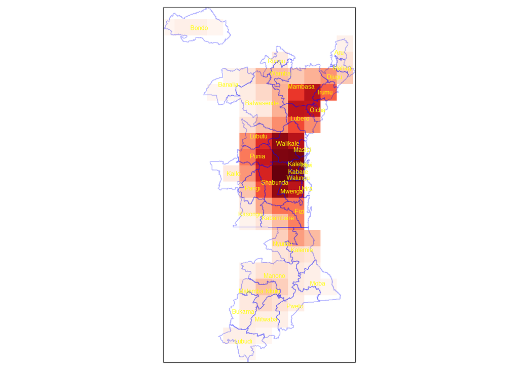

```r
tm_shape(masked_kde, bbox = bounding_box) + tm_raster("Hotspot", style = "quantile",
n = 100,
legend.show = FALSE,
palette = "Reds") +
tm_shape(territories) + tm_borders(alpha=.3, col = "blue") +
tm_layout(frame = TRUE)+ tm_text("NOM", col = "yellow", size = .50)
```

## Spatial interpolation

Given a set of measures $x_{1},\ldots,x_{i},\ldots,x_{n}$ (mean number of workers, number of non state group army,..) in different locations(artisanal mining sites), the aim of interpolation is to predict value $x_{j}$ at location where no measurements have been made. We encounter several spatial interpolation techniques in the literature,for example:

1. **Thiessen Polygon**: Assigns interpolated value equal to the value found at the nearest sample location. Only one point used, the nearest. Accuracy depends largely on sampling density.
2. **Inverse Distance Weighted (IDW)**: Assigns interpolated value after using the distance and values to nearby know points.Weight of each sample point is an inverse proportion to the distance. The further away the point, the less is the weight.The value $x_j$ is given by:
   $$x_{j} = \frac{\sum_{ i =1}^{n}x_{i}\omega_{ij}}{\sum_{ i =1}^{n}\omega_{ij}}$$
   Where $\omega_{ij} = \frac{1}{d_{ij}^{\alpha}}$, $d_{ij}$ is the distance between $x_{j}$ and $x_{i}$ ,and $\alpha$ a user defined coefficient.
3. **Kriging**: The most used interpolation method that relies on spatial autocorrelation. Kriging uses the *minimum variance method* to calculate the weights.

For every pair on points $(x_i,x_j)$, defines the distance $h_{ij} = (x_i – x_j)$. $h_{ij}$ is the called *lag distance* between point i and j. The *Semi-variance* is given by $\gamma(h)=\frac{1}{2n} (x_i - x_j)^{2}$. For similar points, the distance $(x_i-x_j)$ is small and the semivariance is also small. A *variogram* is the plot of semi-variance for a range of lag distances.A set of points are used to estimate the shape of the variogram(a line is fit through the set of semi-variance points) which is considered as model to interpolate the entire surface.

### Inverse Distance Weighted.

We will run the the model on DRC’s territories without katanga and then test with artisanal mining sites of katanga.

```r
katanga <-c("Lubudi", "Mitwaba","Bukama", "Pweto", "Moba", "Manono", "Malemba-Nkulu", "Kalemie", "Nyunzu")
```

Extract training set

```r
trainSet <-subset(territories, !(NOM %in% katanga))
trainSet
```

```
## Object of class "SpatialPolygonsDataFrame" (package sp):
##
## Number of SpatialPolygons:  28
##
## Variables measured:
##           NOM sumIs_3t_mine sumIs_gold_mine sumPresence meanWorkers_numb
## 64    Banalia             0               6           6        107.50000
## 65 Bafwasende             2              63          65         72.63889
## 73      Bondo             0              12           0        283.66667
## 77      Rungu             0               0           1         13.00000
## 82      Wamba             0              14          14        124.78571
## 83      Irumu             0              85          69        101.29412
## ...
```

Extract testing set.

```r
testingSet <-subset(territories, NOM %in% katanga)
testingSet
```

```
## Object of class "SpatialPolygonsDataFrame" (package sp):
##
## Number of SpatialPolygons:  9
##
## Variables measured:
##         NOM sumIs_3t_mine sumIs_gold_mine sumPresence meanWorkers_numb
## 110  Lubudi             3               0           0        335.00000
## 117 Kalemie             8              56          33         82.91935
## 118    Moba             0               6           6        147.00000
## 119  Manono            36               0           1        232.54054
## 122  Nyunzu            28              14           3        108.11905
## 126   Pweto             2               6           0         57.25000
## ...
```

Root mean square error for Model comparison.

```r
RMSE <- function(observed, predicted) {
  sqrt(mean((predicted - observed)^2, na.rm=TRUE))
}
```

```r
library(gstat)
library(xts)
```

Running IDW on training set for mean number of workers and making prediction on testing set.

```r
# runs the idw for the Price variable of House.Points
idw <- idw(trainSet$meanWorkers_numb ~ 1, locations = trainSet, newdata= testingSet)
```

```
## [inverse distance weighted interpolation]
```

Getting predicted values.

```r
idw$var1.pred
```

```
## [1] 118.2505 123.6985 120.6556 118.0511 118.5717 119.2902 117.6599 117.7590
## [9] 118.3921
```

RMSE value.

```r
RMSE(testingSet@data$meanWorkers_numb,idw$var1.pred)
```

```
## [1] 102.5044
```

We will Transform predicted values to raster and plot it with territories.

Convert idw output to dataframe.

```r
idwPredict = as.data.frame(idw)
names(idwPredict)[1:3] <- c("long", "lat", "prediction")
idwPredict <-subset(idwPredict, select=-var1.var)
```

Create spatial points data frame.

```r
spg <- idwPredict
coordinates(spg) <- ~ long + lat
```

Coerce to SpatialPixelsDataFrame then to raster.

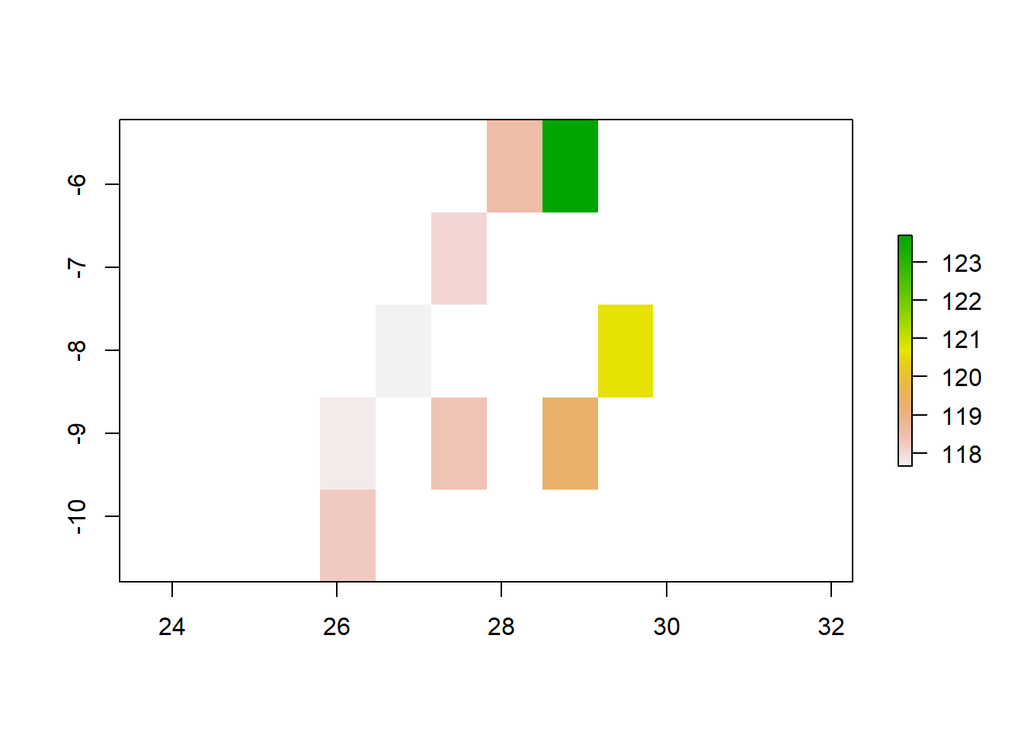

```r
pixels <- SpatialPixelsDataFrame(spg, tolerance = 0.760784, spg@data)
rasterPredicted <- raster(pixels[,'prediction'])

projection(rasterPredicted) <- CRS(proj4string(dataIPIS))

plot(rasterPredicted)
```

Back the raster by the test set map.

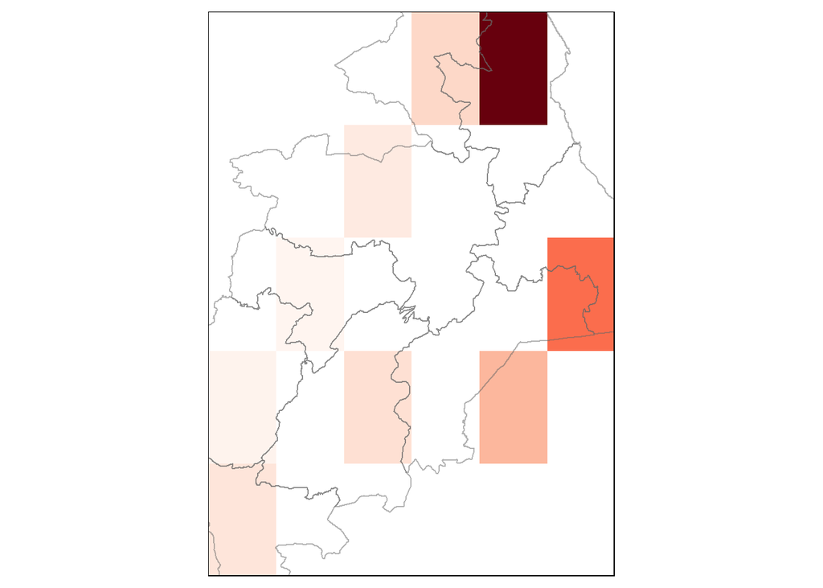

```r
tm_shape(rasterPredicted) + tm_raster("prediction", style = "quantile", n = 100,
palette = "Reds", legend.show = FALSE) +
tm_shape(testingSet) + tm_borders(alpha=.5)
```

### Kriging:

Unlike **gstat** package, **automap** package offers the function **autoKrige** which allows to carry out the kriging in one step without calculating variogram, fit model and krige.

```r
library(automap)
```

The train set is a spatial polygon. To run the kriging, we transform it into spatial point taking the centroid of each territory.

```r
trainSet.pts<-SpatialPointsDataFrame(coords= rgeos::gCentroid(trainSet,byid=TRUE), data=trainSet@data, proj4string = CRS(proj4string(dataIPIS)))

trainSet.pts
```

```
## class       : SpatialPointsDataFrame
## features    : 28
## extent      : 24.09862, 30.71433, -4.547249, 4.194597  (xmin, xmax, ymin, ymax)
## crs         : +proj=longlat +datum=WGS84 +no_defs
## variables   : 5
## names       :   NOM, sumIs_3t_mine, sumIs_gold_mine, sumPresence, meanWorkers_numb
## min values  :   Aru,             0,               0,           0,               13
## max values  : Wamba,            79,             216,         175, 299.234042553192
```

The testing set is a spatial polygon. To run the kriging, we transform it into spatial point taking the centroid of each territory.

```r
testingSet.pts<-SpatialPointsDataFrame(coords= rgeos::gCentroid(testingSet,byid=TRUE), data=testingSet@data, proj4string = CRS(proj4string(dataIPIS)))

testingSet.pts
```

```
## class       : SpatialPointsDataFrame
## features    : 9
## extent      : 26.12786, 29.54756, -10.2253, -5.731306  (xmin, xmax, ymin, ymax)
## crs         : +proj=longlat +datum=WGS84 +no_defs
## variables   : 5
## names       :    NOM, sumIs_3t_mine, sumIs_gold_mine, sumPresence, meanWorkers_numb
## min values  : Bukama,             0,               0,           0,            57.25
## max values  :  Pweto,            50,              56,          33,              335
```

Lat-long is not a projected CRS, we need to reproject to some else in order to run kriging with automap.

```r
trainSet.pts <- spTransform(trainSet.pts, "+init=EPSG:27562")

testingSet.pts <- spTransform(testingSet.pts, "+init=EPSG:27562")
```

Running the kriging.

```r
kriging = autoKrige(meanWorkers_numb ~ 1, trainSet.pts, testingSet.pts)
```

```
## [using ordinary kriging]
```

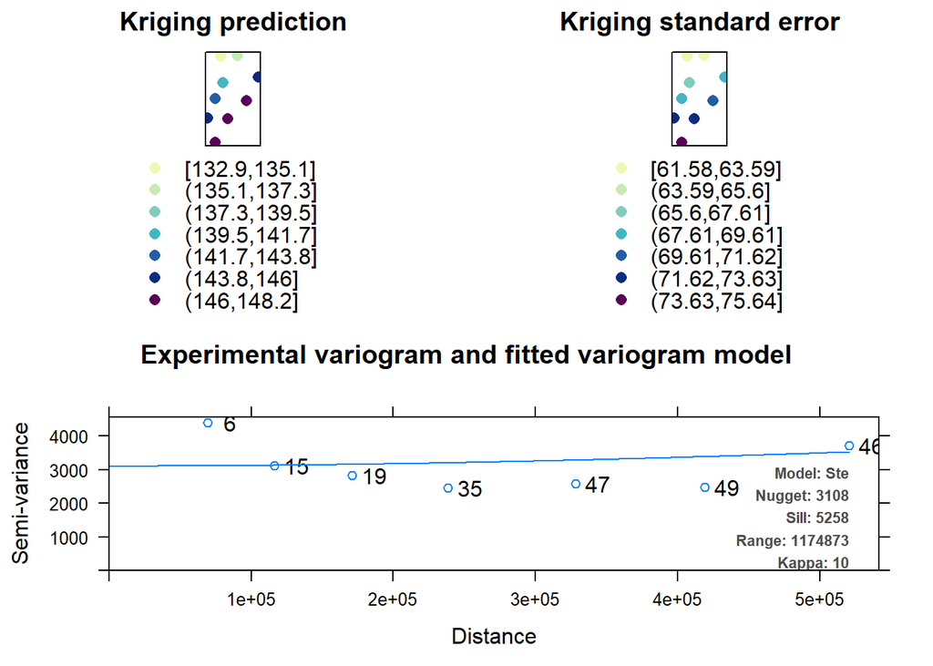

```r
plot(kriging)
```

Getting predicted data.

```r
kriging$krige_output@data$var1.pred
```

```
## [1] 148.2202 136.2091 144.7913 139.9638 132.9191 146.3522 142.2280 144.9391
## [9] 146.5394
```

Getting RMSE. Kriging more accurate than IDW.

```r
RMSE(testingSet@data$meanWorkers_numb, kriging$krige_output@data$var1.pred )
```

```
## [1] 89.68559
```

We will back from centroids to territories.

Back to lat-lon CRS.

```r
predicted.pts <-kriging$krige_output
predicted.pts <- spTransform(predicted.pts, proj4string(dataIPIS))
predicted.pts
```

```
## class       : SpatialPointsDataFrame
## features    : 9
## extent      : 26.12768, 29.54728, -10.22897, -5.734652  (xmin, xmax, ymin, ymax)
## crs         : +proj=longlat +datum=WGS84 +no_defs
## variables   : 3
## names       :        var1.pred,         var1.var,       var1.stdev
## min values  : 132.919050902658,  3792.5478427941, 61.5836653894042
## max values  : 148.220248505955, 5720.75938868806, 75.6357018126233
```

keep only predicted value.

```r
predicted.pts@data <-data.frame(predicted.pts@data[,"var1.pred"])
names(predicted.pts@data) <-"prediction"
predicted.pts
```

```
## class       : SpatialPointsDataFrame
## features    : 9
## extent      : 26.12768, 29.54728, -10.22897, -5.734652  (xmin, xmax, ymin, ymax)
## crs         : +proj=longlat +datum=WGS84 +no_defs
## variables   : 1
## names       :       prediction
## min values  : 132.919050902658
## max values  : 148.220248505955
```

Coerce to SpatialPixelsDataFrame then to raster.

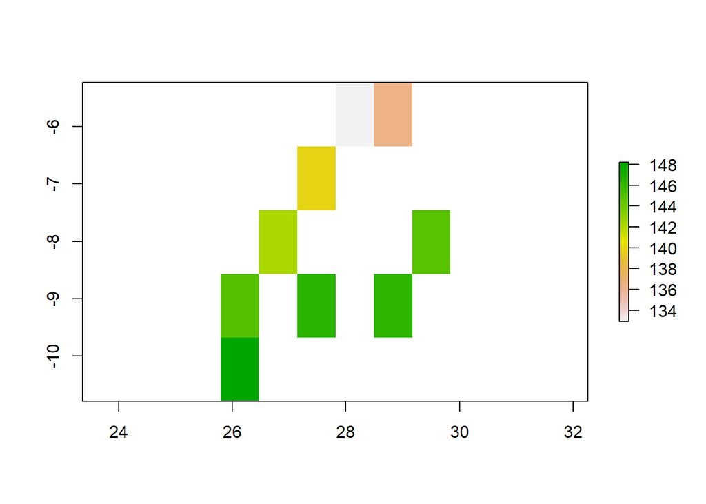

```r
pixels <- SpatialPixelsDataFrame(predicted.pts, tolerance = 0.760784, predicted.pts@data)
rasterPredicted <- raster(pixels[,'prediction'])

projection(rasterPredicted) <- CRS(proj4string(dataIPIS))

plot(rasterPredicted)
```

Back the raster by the test set map.

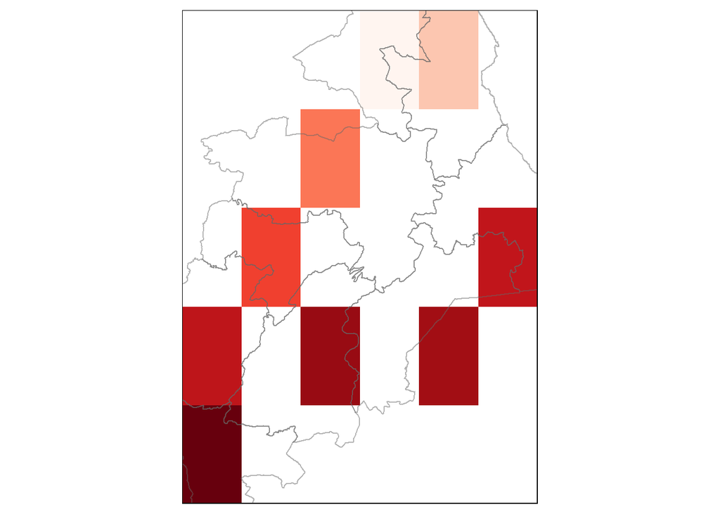

```r
tm_shape(rasterPredicted) + tm_raster("prediction", style = "quantile", n = 100,
palette = "Reds", legend.show = FALSE) +
tm_shape(testingSet) + tm_borders(alpha=.5)
```

**We get better result with Kriging. Inverse Distance Weighted did not fit territories spatial data.**

## Geographically weighted regression

Geographically weighted regression(GWR) is the extension of regression where the stationary process is not assumed. If we consider globally our data,the prediction of mean number of workers can be obtained using:
$$y_{i} = \beta_{0} + \sum_{j =1}^{m} \beta_{j}x_{ji} + \epsilon_{i}$$
where $\beta_{0}$ the intercept, $\beta = (\beta_{1},\ldots,\beta_{m})$ regression model coefficient, $\epsilon$ residual and $x_{ji}$ independant variables(is_3t_mine,is_gold_mine,presence). Recall that the estimator of $\beta$ is:
$$\hat{\beta} = (X^{t}X)^{-1}X^{t}Y$$

The coefficient $\hat{\beta}$ is the same over the space. However the administration is different across DRC territories, infuence of army group is different because the government in Kinshasa does not control the whole country,…

The GWR take into account this spatial variability and autocorrelation, and introduces the weight $\omega$. So,
$$y_{i} = \beta_{0}(i) + \sum_{j =1}^{m} \beta_{j}(i)x_{ji} + \epsilon_{i}$$
, the estimator is:
$$\hat{\beta}(i) = (X^{t}W(i) X)^{-1}X^{t}W(i)Y$$

where $W(I)$ is a weight matrix diagonal for specific location $I$ so that nearby observation are given greather weight than further away.
$$W(i) = \begin{pmatrix}
w_{i1} & 0 &\ldots & 0\\
0 & w_{i1} & \ldots & 0\\
\ldots & \ldots & \ldots & \ldots\\
0 & 0 &\ldots & w_{im}
\end{pmatrix}$$

$w_{im}$ is the weight given to point $m$ for the estimate of the local parameters at location $i$. There are a range for weighting calibration, for instance:
$$w_{ij} = \exp \{-\frac{1}{2} (\frac{d_{ij}}{h})^{2}\}$$
or
$$w_{ij}=
\begin{cases}
( 1-\frac{d_{ij}^{2}}{h^{2}})^{2}, & \text{if j is one of the Nth nearest neighbours of i}\ a=1 \\
0, & \text{otherwise}
\end{cases}$$

where $d_{ij}$ is the distance between locations $i$ and $j$ and $h$ is the bandwidth.

GWR is used as a data exploration technique that allows to identify if locally weighted regression coefficients may vary across the study area.

We first run global regression model wiht territories data.

```r
modelGlobal <- lm(territories$meanWorkers_numb ~ territories$sumIs_3t_mine+territories$sumIs_gold_mine +territories$sumPresence)
summary(modelGlobal)
```

```
##
## Call:
## lm(formula = territories$meanWorkers_numb ~ territories$sumIs_3t_mine +
##     territories$sumIs_gold_mine + territories$sumPresence)
##
## Residuals:
##      Min       1Q   Median       3Q      Max
## -123.998  -43.466   -8.646   24.136  196.135
##
## Coefficients:
##                             Estimate Std. Error t value Pr(>|t|)
## (Intercept)                 137.7070    17.2334   7.991 3.22e-09 ***
## territories$sumIs_3t_mine     0.3861     0.6102   0.633    0.531
## territories$sumIs_gold_mine   0.1977     0.5922   0.334    0.741
## territories$sumPresence      -0.7085     0.7699  -0.920    0.364
## ---
## Signif. codes:  0 '***' 0.001 '**' 0.01 '*' 0.05 '.' 0.1 ' ' 1
##
## Residual standard error: 73.59 on 33 degrees of freedom
## Multiple R-squared:  0.07375,    Adjusted R-squared:  -0.01045
## F-statistic: 0.8759 on 3 and 33 DF,  p-value: 0.4635
```

To run the GWR regression, we need first to calculate a kernel bandwidth.

```r
library("spgwr")
GWRbandwidth <- gwr.sel(territories$meanWorkers_numb ~ territories$sumIs_3t_mine +
    territories$sumIs_gold_mine + territories$sumPresence, data=territories, adapt =TRUE)
```

Now we can run GWR.

```r
gwrModel = gwr(territories$meanWorkers_numb ~ territories$sumIs_3t_mine +
    territories$sumIs_gold_mine + territories$sumPresence, data=territories, adapt=GWRbandwidth, hatmatrix=TRUE, se.fit=TRUE)
```

Results of the GWR.

```r
gwrModel
```

```
## Call:
## gwr(formula = territories$meanWorkers_numb ~ territories$sumIs_3t_mine +
##     territories$sumIs_gold_mine + territories$sumPresence, data = territories,
##     adapt = GWRbandwidth, hatmatrix = TRUE, se.fit = TRUE)
## Kernel function: gwr.Gauss
## Adaptive quantile: 0.9459502 (about 35 of 37 data points)
## Summary of GWR coefficient estimates at data points:
##                                   Min.    1st Qu.     Median    3rd Qu.
## X.Intercept.                129.907110 130.990537 132.502260 134.467702
## territories.sumIs_3t_mine     0.340581   0.344638   0.358147   0.407921
## territories.sumIs_gold_mine   0.073085   0.123551   0.221132   0.269911
## territories.sumPresence      -0.763378  -0.736234  -0.643864  -0.574339
##                                   Max.   Global
## X.Intercept.                139.264715 137.7070
## territories.sumIs_3t_mine     0.429001   0.3861
## territories.sumIs_gold_mine   0.284696   0.1977
## territories.sumPresence      -0.560742  -0.7085
## Number of data points: 37
## Effective number of parameters (residual: 2traceS - traceS'S): 4.811491
## Effective degrees of freedom (residual: 2traceS - traceS'S): 32.18851
## Sigma (residual: 2traceS - traceS'S): 73.10572
## Effective number of parameters (model: traceS): 4.431729
## Effective degrees of freedom (model: traceS): 32.56827
## Sigma (model: traceS): 72.67825
## Sigma (ML): 68.1869
## AICc (GWR p. 61, eq 2.33; p. 96, eq. 4.21): 430.5973
## AIC (GWR p. 96, eq. 4.22): 421.8799
## Residual sum of squares: 172029.8
## Quasi-global R2: 0.1084872
```

Quasi globally r squared is 10% and locally coefficents remain close to the global coefficient.

We now try to vizualise stationarity of coefficients and localR2.

```r
resultsLocal <-as.data.frame(gwrModel$SDF)
gwrMap <- cbind(territories, as.matrix(resultsLocal))
```

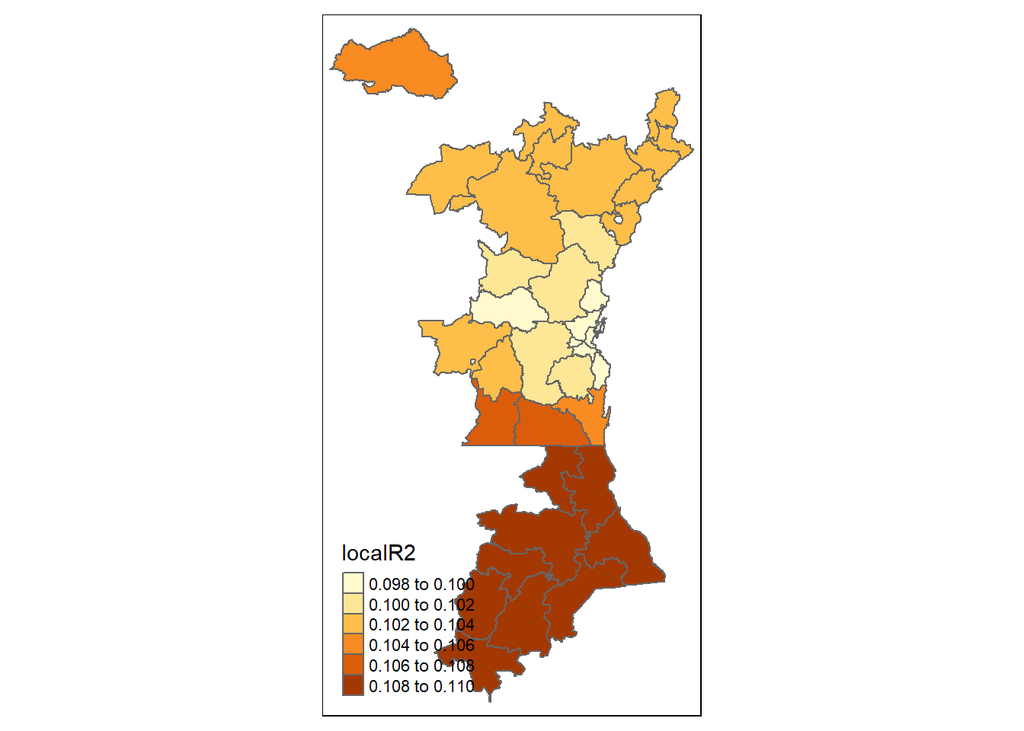

```r
qtm(gwrMap, fill = "localR2")
```

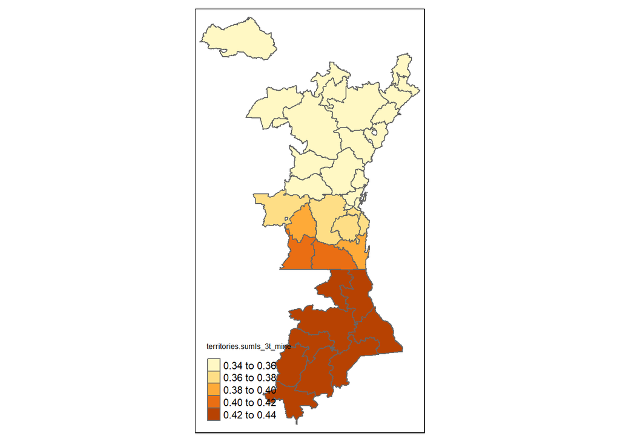

```r
qtm(gwrMap, fill = "territories.sumIs_3t_mine")
```

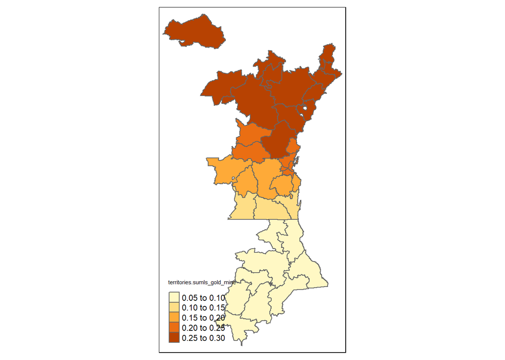

```r
qtm(gwrMap, fill = "territories.sumIs_gold_mine")
```

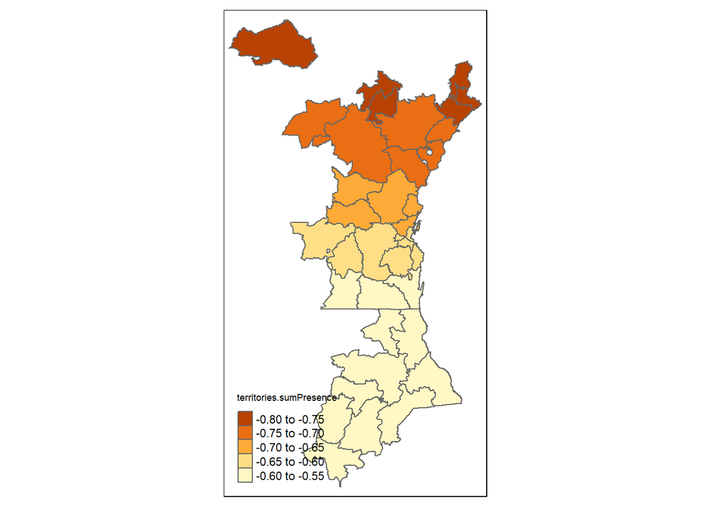

```r
qtm(gwrMap, fill = "territories.sumPresence")
```

## Clustering spatial data

The aim of spatial clustering is to group a set of geographic units in such a way that geographic units in the same group are more similar to each other than to those in other groups. Two clustering techniques are mostrly used in spatial analysis:

### Geodemographic

The clustering algorithm is applied only to non spatial attributes and spatial units are assigned to the cluster of their non spatial attributes. We present bellow ***Kmeans*, one of the simplest clustering algorithm.

Let $X = \{x_1, . . . , x_n\}$ be a set of $n$ spatial units, each with $d$ non spatial attributes.

The Kmeans problem aims to find a set of $k$ groups of spatial which minimizes the function
$$f(M) = \sum_{x \in X} \min_{\mu \in M}|| x- \mu||^{2}_{2}$$
where $M =\{\mu_{1},\ldots,\mu_{k}\}$, $\mu_{k}$ is the centroid and $k$ the number of the clusters and the input parameter.

**Step of the Kmeans clustering** 1.Choose $k$ initial centroids $µ_1,\ldots, µ_k$ randomnly from the set $X$. 2.For each point $x \in X$, find the closest centroid $µ_i$ and add $x$ to a set $S_i$. 3.For $i = 1,\ldots k$, set $µ_i$ to be the centroid of the points in $S_i$. 4. Repeat steps 2 and 3 until all centroids do not change or $f(M)$ be less a given precision.

### Regionalization

Regionalization called also constrained spatial clustering aims to aggregate the geographic units into a number of spatially contiguous groups while optimizing an objective function, which is normally a measure of the attribute similarity in each group. REDCAP (GUO 2008) and SKATER are the most used regionalization techniques.

Running Kmeans with territories data for 4 clusters.The result’s of Kmeans depends of randomly chosen centroids, so we ask R to run the model 50 times and choose the best. Data are also scaled.

```r
territoriesKmeans<- kmeans(scale(territories@data[, -1]), 4, nstart = 50)
territoriesKmeans
```

```
## K-means clustering with 4 clusters of sizes 4, 19, 6, 8
##
## Cluster means:
##   sumIs_3t_mine sumIs_gold_mine sumPresence meanWorkers_numb
## 1    1.10145041      2.45571795   2.4482419       -0.6009585
## 2   -0.64852544     -0.32138564  -0.2804764       -0.3447683
## 3   -0.03389977     -0.52701163  -0.5840792        1.8745291
## 4    1.01494754     -0.06930937  -0.1199300       -0.2865927
##
## Clustering vector:
##  64  65  73  77  82  83  84  85  86  87  89  90  91  93  94  95  96  97  98  99
##   2   2   3   2   2   2   1   3   2   2   1   1   2   4   4   2   2   4   1   4
## 100 101 102 104 105 106 107 108 110 117 118 119 122 126 178 179 180
##   2   2   2   4   4   2   2   4   3   2   2   3   4   2   3   2   3
##
## Within cluster sum of squares by cluster:
## [1] 11.215357 16.052887  6.414493  8.360497
##  (between_SS / total_SS =  70.8 %)
##
## Available components:
##
## [1] "cluster"      "centers"      "totss"        "withinss"     "tot.withinss"
## [6] "betweenss"    "size"         "iter"         "ifault"
```

Add cluster id as territories variable and vizualise.

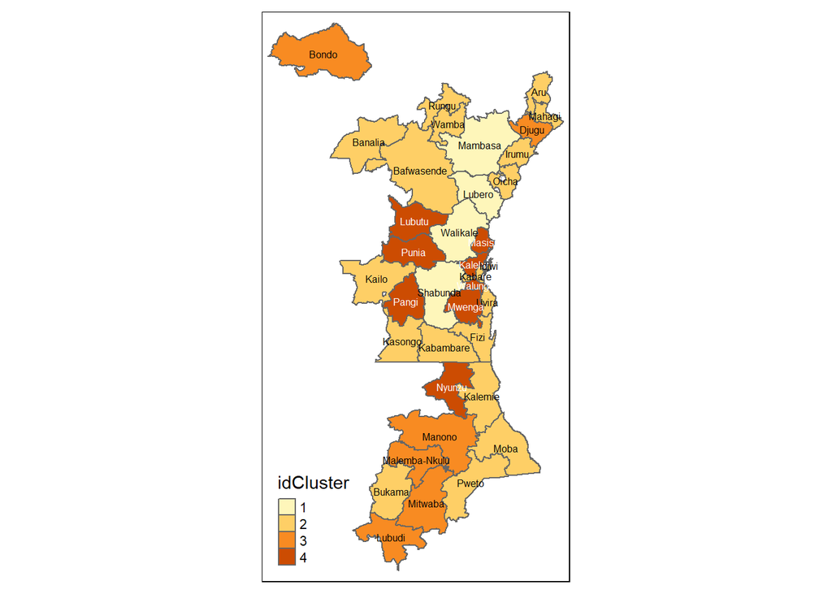

```r
territories@data$idCluster <-territoriesKmeans$cluster
qtm(territories, fill = "idCluster", text = "NOM", text.size = 0.5)
```

Means values by clusters.

```r
aggregate(territories@data[, 2:5], list(territories@data$idCluster), mean)
```

```
##   Group.1 sumIs_3t_mine sumIs_gold_mine sumPresence meanWorkers_numb
## 1       1     44.250000       180.25000 140.7500000         89.19961
## 2       2      3.789474        21.73684  14.8421053        107.95600
## 3       3     18.000000        10.00000   0.8333333        270.43687
## 4       4     42.250000        36.12500  22.2500000        112.21520
```

We will apply regionalization to territory data.

```r
territoriesSt <- scale(territories@data[,c('sumIs_3t_mine','sumIs_gold_mine','sumPresence','meanWorkers_numb')])
summary(territoriesSt)
```

```
##  sumIs_3t_mine     sumIs_gold_mine    sumPresence       meanWorkers_numb
##  Min.   :-0.8124   Min.   :-0.7022   Min.   :-0.60214   Min.   :-1.6418
##  1st Qu.:-0.8124   1st Qu.:-0.6496   1st Qu.:-0.60214   1st Qu.:-0.6867
##  Median :-0.4664   Median :-0.4569   Median :-0.47210   Median :-0.3445
##  Mean   : 0.0000   Mean   : 0.0000   Mean   : 0.00000   Mean   : 0.0000
##  3rd Qu.: 0.5716   3rd Qu.: 0.1212   3rd Qu.: 0.02636   3rd Qu.: 0.3136
##  Max.   : 2.6044   Max.   : 3.0820   Max.   : 3.19052   Max.   : 2.7564
```

Neighbor list

```r
territoriesNb <- poly2nb(territories)
summary(territoriesNb)
```

```
## Neighbour list object:
## Number of regions: 37
## Number of nonzero links: 134
## Percentage nonzero weights: 9.788167
## Average number of links: 3.621622
## 2 regions with no links:
## 73 100
## Link number distribution:
##
##  0  1  2  3  4  5  6  7 11
##  2  2  4 13  7  4  2  2  1
## 2 least connected regions:
## 64 87 with 1 link
## 1 most connected region:
## 98 with 11 links
```

Calculing costs

```r
#lcosts <- nbcosts(territoriesNb, territoriesSt)
#head(lcosts)
```

Making listw

```r
#territoriesW <- nb2listw(territoriesNb,lcosts,style="B")
#summary(territoriesW)
```

Minimum spanning tree

```r
#territoriesmst <- mstree(territoriesW)
#head(territoriesmst)
```

Contiguity-constrained cluster

```r
#clusters <- skater(territoriesmst[,1:2],territoriesSt,3)
#clusters
```